## R & Vador

La force {purrr}

[figure not shown]

## Contexte

- {purrr} est un package faisant partie de {tidyverse}
- Permet de faire de la Programmation fonctionnelle
- Fonction qui utilise en argument une autre fonction

## Exemple

## Connaitre la répartition totale des avoirs des clients par type d’encours

## Répartition des avoirs des clients

```r
str(info_pf)
```

```
## tibble [4,998 × 7] (S3: tbl_df/tbl/data.frame)
##  $ id_client  : int [1:4998] 2910 4265 4152 635 4341 1620 172 537 3503 505 ...
##  $ credit     : num [1:4998] 7270743 9617394 2105214 19234146 3034923 ...
##  $ action     : num [1:4998] 3253059 11133848 10929797 20170566 6764541 ...
##  $ cash       : num [1:4998] 15904187 3618495 24469691 20609744 2757515 ...
##  $ autre      : num [1:4998] 10295377 24295656 3148606 10435149 4237789 ...
##  $ type_client: chr [1:4998] "Private Banking" "Private Banking" "Private Banking" "CFG" ...
##  $ year       : int [1:4998] 2017 2018 2018 2017 2015 2015 2018 2017 2015 2019 ...
```

- Dataset avec 4 type d’encours de 2015 à 2019
- crédit, cash, action et autre

On veut connaitre le montant total  
par classe d’actif en 2019

## Filtre les données sur 2019

```r
pf2019 <- info_pf %>%
  filter(year==2019)
```

## Boucle

```r
n <- 4
actifs <- c("credit", "action", "cash", "autre")

# Creation Matrice resultat
loop_res <- matrix(nrow=0, ncol=n,
                   dimnames = list(NULL, actifs))

# Creation boucle
for(actif in actifs){
  loop_res[actif] <- sum(pf2019[actif])
}

loop_res
```

```
##     credit     action       cash      autre
## 9767677826 9630040869 9913061591 9332205252
```

## Programmation Fonctionnelle

```r
# Les etapes creation matrice resultat & boucle
# se font au meme niveau
fp_res <-  pf2019 %>%
  select(c("credit", "action", "cash","autre")) %>%
  map_df(sum)

fp_res
```

```
## # A tibble: 1 × 4
##        credit      action        cash       autre
##         <dbl>       <dbl>       <dbl>       <dbl>
## 1 9767677826. 9630040869. 9913061591. 9332205252.
```

## Le même résultat

- Mais la programmation fonctionnelle est plus direct
- Voyons la logique qui s’y applique

## Fonctionnement de `map`

## Fonctionnement de `map`

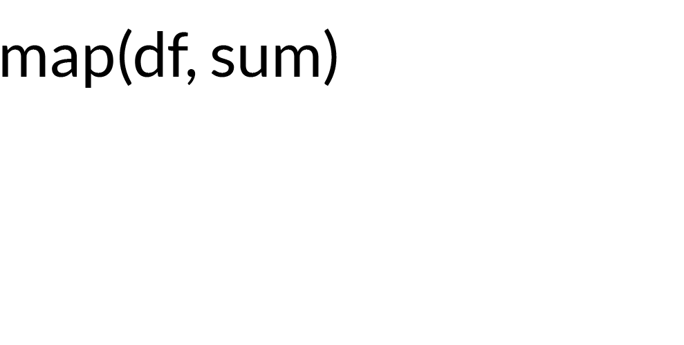

## Fonctionnement de `map`

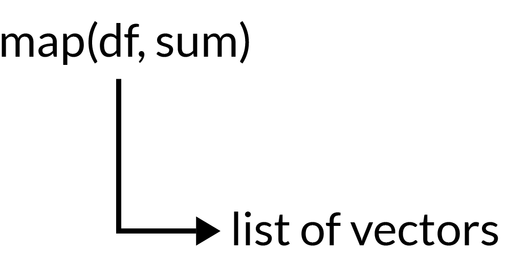

## Fonctionnement de `map`

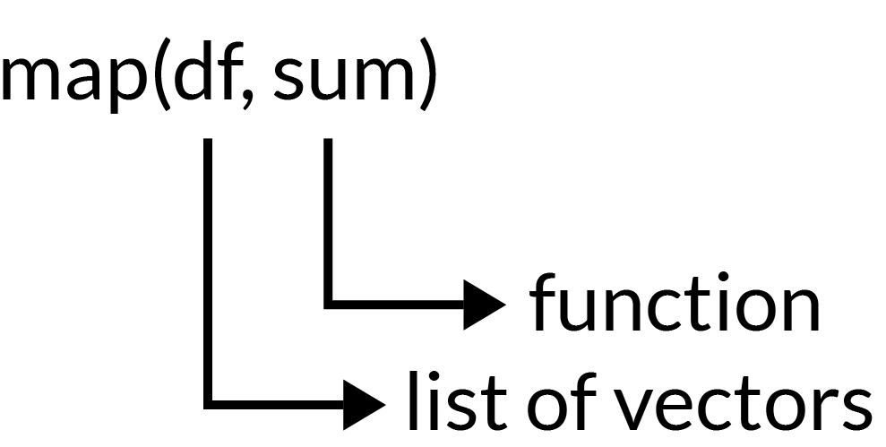

## Illustration

## Avec plusieurs colonnes

`map(df, sum)`

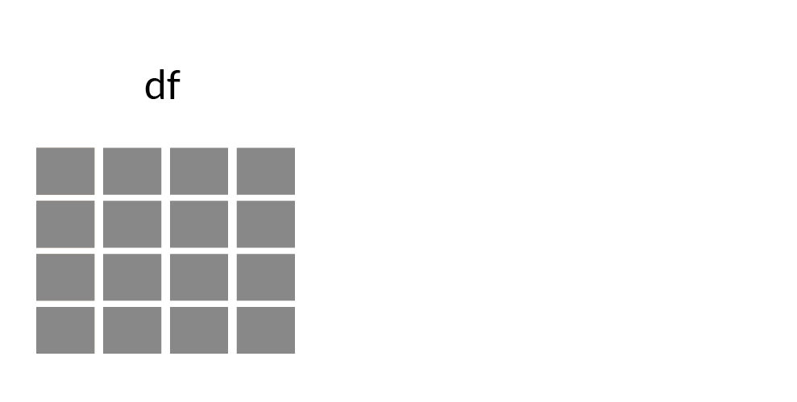

## Avec plusieurs colonnes

`map(df, sum)`

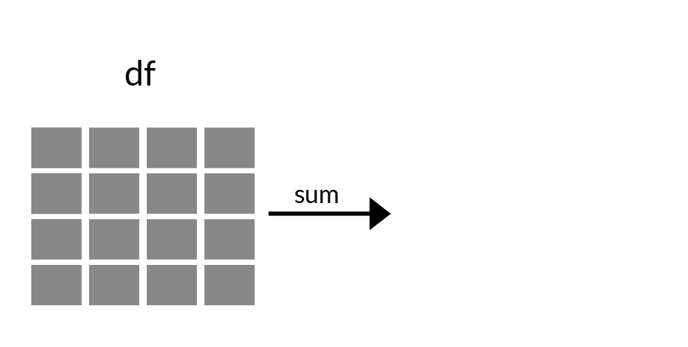

## Avec plusieurs colonnes

`map(df, sum)`

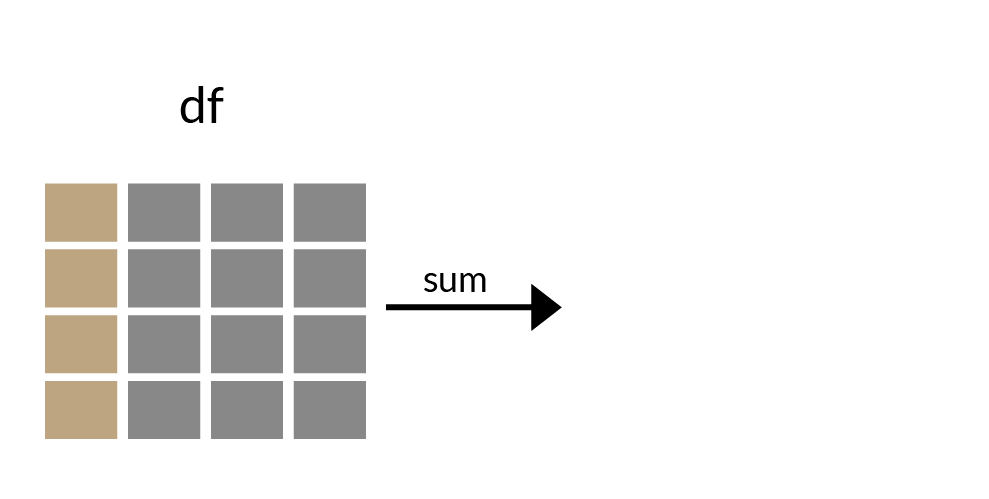

## Avec plusieurs colonnes

`map(df, sum)`

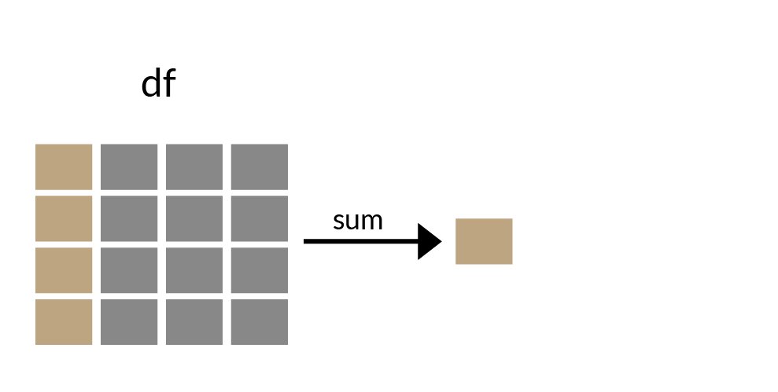

## Avec plusieurs colonnes

`map(df, sum)`

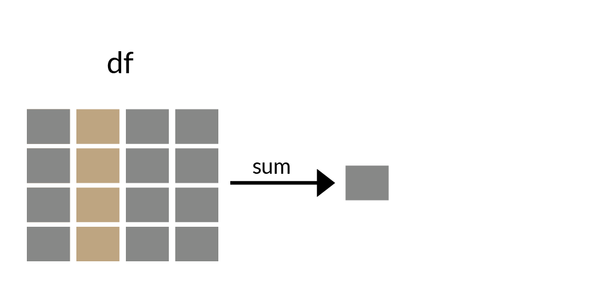

## Avec plusieurs colonnes

`map(df, sum)`

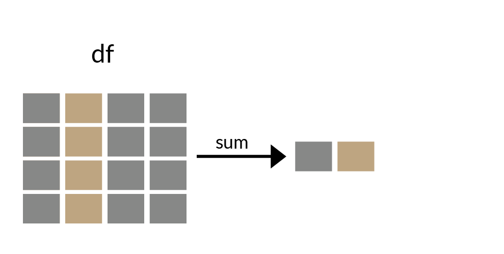

## Avec plusieurs colonnes

`map(df, sum)`

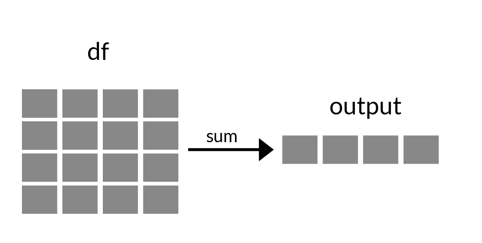

## Avec une colonne

`map(df, exp)`

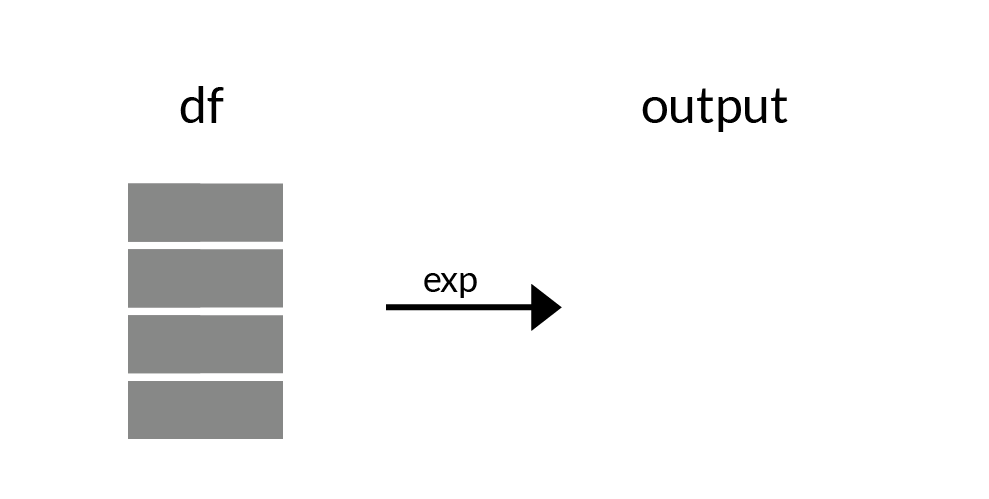

## Avec une colonne

`map(df, exp)`

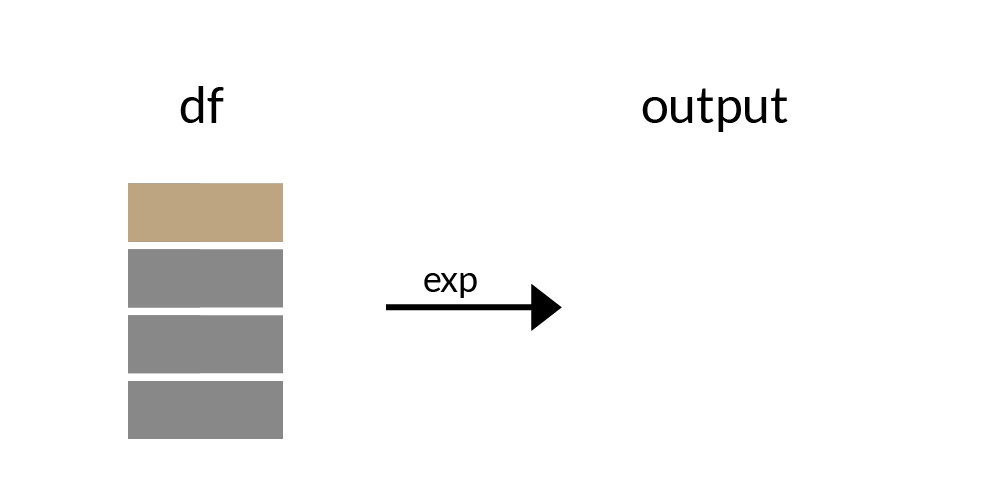

## Avec une colonne

`map(df, exp)`

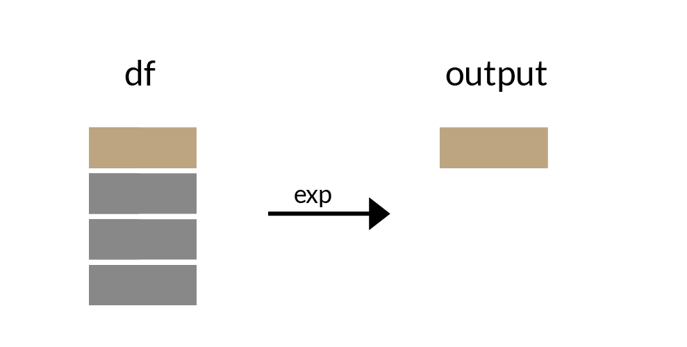

## Avec une colonne

`map(df, exp)`

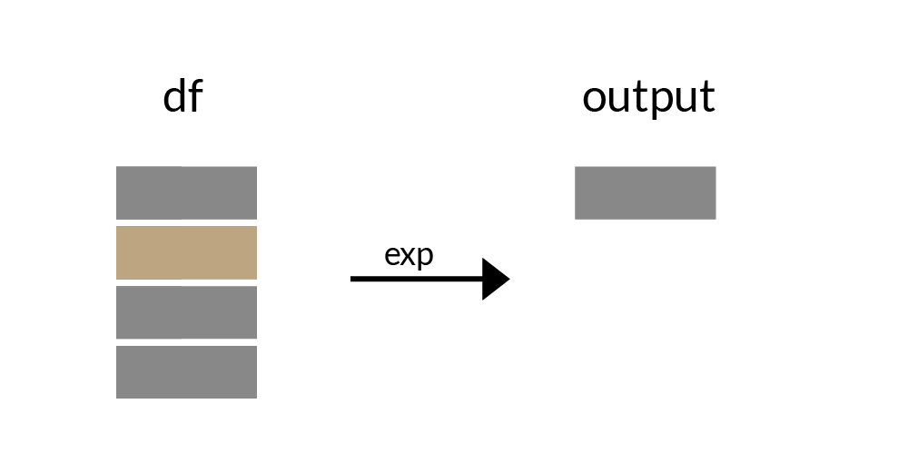

## Avec une colonne

`map(df, exp)`

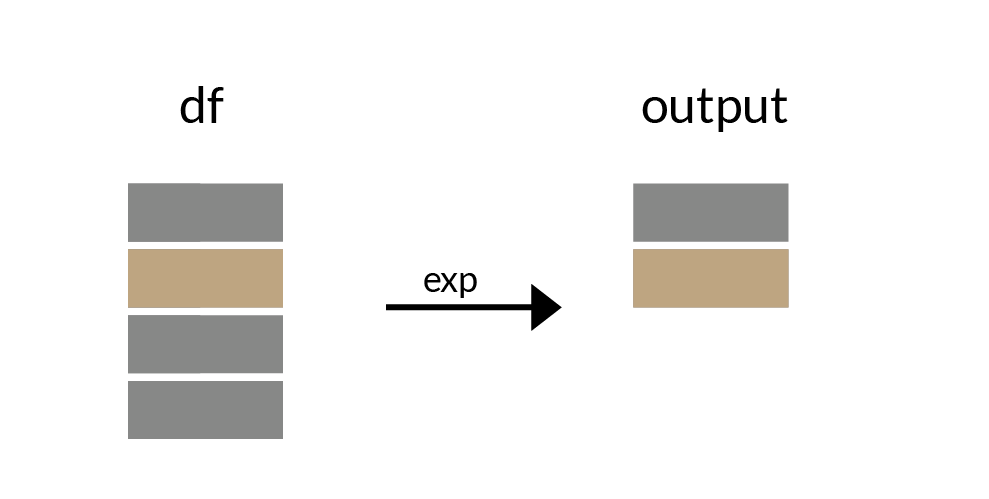

## Avec une colonne

`map(df, exp)`

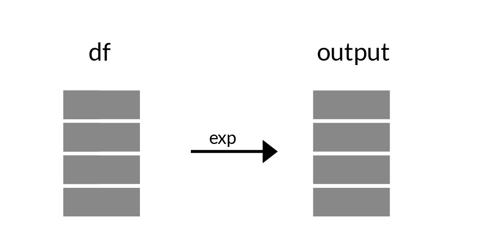

## Famille `map()`

- `map` retourne une liste
- `map_df` retourne un dataframe
- `map_int` retourne vecteur integer
- `map_chr` retourne vecteur caractere
- `map2` va prendre 2 arguments (x, y, function)
- `pmap` va prendre p arguments (list, function)

## `walk()`

- Même principe que `map()` -> (x, function)
- Retourne aucun objet
- Parfait pour sauvegarder ou afficher des éléments

## Cas Pratique

Automatiser la création de graphique par type de clients  
et les insérer dans un PowerPoint

## Regroupe les données par rapport au type de clients

```r
pf <- info_pf %>%
  select(id_client, cash, type_client, year) %>%
  group_by(type_client, year) %>%
  summarise(cash= round(sum(cash)/1000000,2)) %>%
  nest()

pf
```

```
## # A tibble: 3 × 2
## # Groups:   type_client [3]
##   type_client      data
##   <chr>            <list>
## 1 CFG              <tibble [5 × 2]>
## 2 Personal Banking <tibble [5 × 2]>
## 3 Private Banking  <tibble [5 × 2]>
```

## Utilisation de `map()`

```r
pf1 <- pf %>%
  mutate(plots = map( data, function(x){ggplot(x) +
                     geom_bar(aes(year, cash), stat='identity') +
                      ggtitle('Montant total en gestion discrétion') +
                     ylab("Montant en millions d'euros") + #ylab("Montant (millions de dollars)")
                     xlab("Année") +
                     theme_bw() +
                     theme(plot.title = element_text(lineheight = 1.1,size = 20,  hjust = 0.5),
                           plot.subtitle = element_text(lineheight = 1.1,  hjust = 0.5),
                           panel.grid.minor = element_blank(),
                           panel.grid.major = element_blank(),
                           panel.border = element_blank(),
                           axis.line.x = element_blank(),
                           legend.position = 'none'
                     )}
                     ))
```

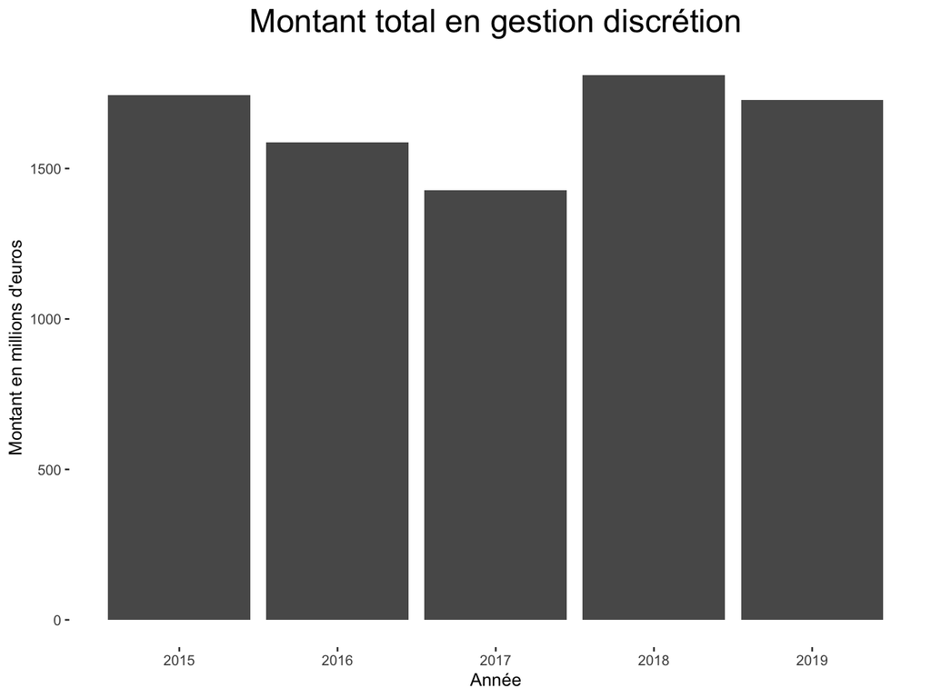

```r
pf1$plots[1]
```

## Utilisation de `map2()`

```r
pf2 <- pf %>%
  mutate(plots = map2( .x=data,.y=type_client, function(x, y){ggplot(x) +
      geom_bar(aes(year, cash), stat='identity') +
      ggtitle('Montant total en cash', subtitle=y) +
      ylab("Montant en millions d'euros") + #ylab("Montant (millions de dollars)")
      xlab("Année") +
      theme_bw() +
      theme(plot.title = element_text(lineheight = 1.1, size = 20,  hjust = 0.5),
            plot.subtitle = element_text(lineheight = 1.1,  hjust = 0.5),
            panel.grid.minor = element_blank(),
            panel.grid.major = element_blank(),
            panel.border = element_blank(),
            axis.line.x = element_blank(),
            legend.position = 'none'
      )}
  ))
```

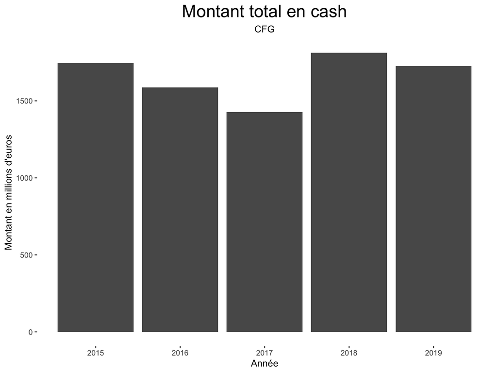

```r
pf2$plots[1]
```

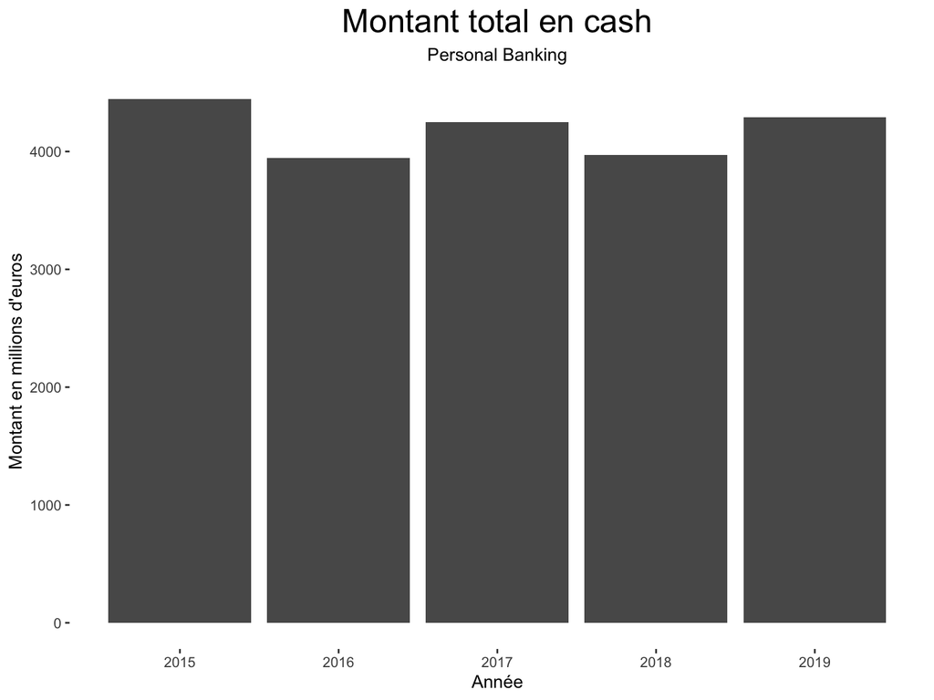

```r
pf2$plots[2]
```

## Utilisation de `pmap()`

```r
pf3 <- pf %>%
  ungroup() %>%
  mutate(fill_color=c('#779cb7', '#36824d', '#bfa4a2'),
         plots = pmap( list(data, type_client, fill_color), function(x, y, z){ggplot(x) +
      geom_bar(aes(year, cash), stat='identity', fill=z) +
      ggtitle('Montant total en gestion discrétion', subtitle=y) +
      ylab("Montant en millions d'euros") + #ylab("Montant (millions de dollars)")
      xlab("Année") +
      theme_bw() +
      theme(plot.title = element_text(lineheight = 1.1,size = 20,  hjust = 0.5),
            plot.subtitle = element_text(lineheight = 1.1,  hjust = 0.5),
            panel.grid.minor = element_blank(),
            panel.grid.major = element_blank(),
            panel.border = element_blank(),
            axis.line.x = element_blank(),
            legend.position = 'none'
      )}
  ))
```

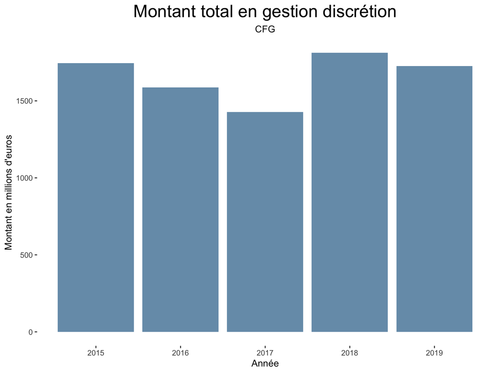

```r
pf3$plots[1]
```

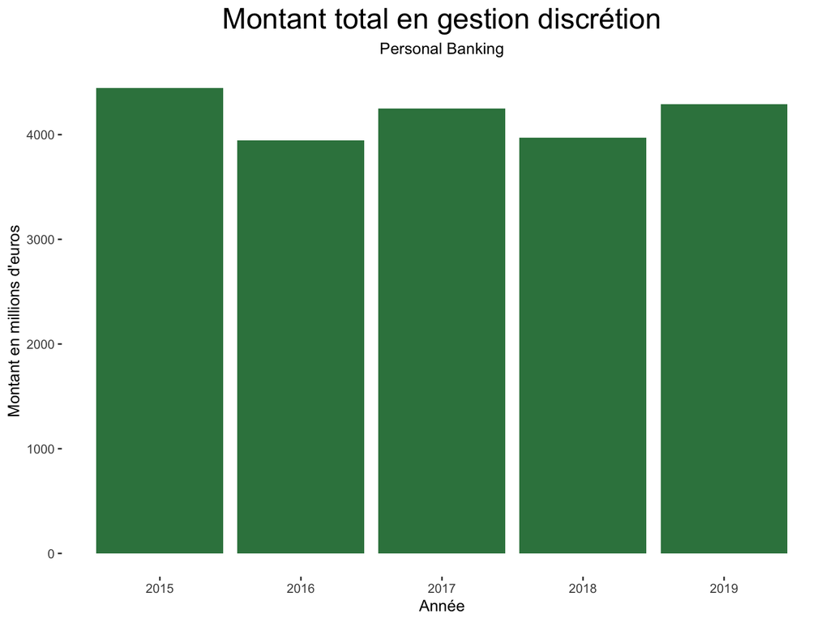

```r
pf3$plots[2]
```

## Sauvegarde dans un Powerpoint

```r
library(rvg)
library(officer)

create_pptx <- function(plot, path){

  read_pptx(path) %>%
    add_slide(layout = "Title and Content", master = "Office Theme") %>%
    ph_with(plot, location = ph_location_fullsize() ) %>%
    print(target = path)
}

walk(tt3$plots, function(x){create_pptx(x, paste0(getwd(),'/test.pptx'))})
```

## Résultat

[figure not shown]

## Résultat

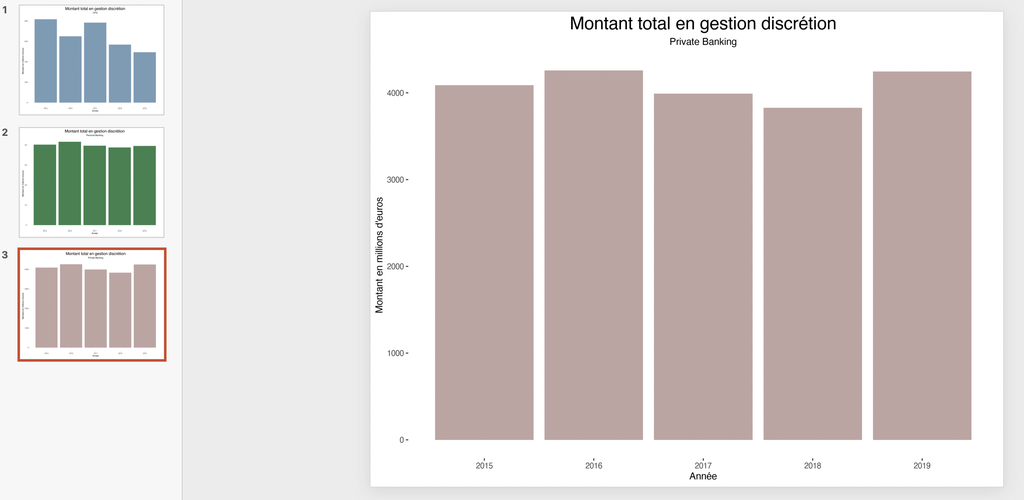

## Récapitulatif

## `map()`

- peut etre utilisé avec %>%
- peut retourner differents types d’objets
- peut prendre plusieurs arguments

Merci pour votre attention

## Questions?

- Pourquoi utiliser les fonctions de {purrr} si les fonctions de type `apply` font la même chose?
- Est-ce que `map` fait les calculs en parallele?